# CITS5506 Essay: The Internet of Underwater Things

Nathan scott: 18913101

# Abstract

The internet of underwater things (IOUT) may have not escaped the IOT hype machine, but a closer look at the applications, issues and implications show that IOUT is most likely not going to be the breakthrough that changes the way mankind lives forever. IOUT will undoubtedly though, become a valuable tool in a complex IOT ecosystem of distributed autonomous sensors.

# Introduction

The underwater realm covers approximately 70% of the surface of the Earth. Human civilisation has lived alongside waterbodies since the dawn of their existence and count water as a critical component to human survival. However humans can not survive in water for any length of time and as such humans, and their IOT networks, inhabit only a small part of even the terrestrial environment. The internet of underwater things relates to internet connected things in water environments. As with the terrestrial IOT case, IOUT is primarily comprised of sensor networks known as UWSN (UnderWater Sensor Networks). The IOUT concept effectively extends man’s ability to connect, observe and control to the worlds oceans and water bodies. The unfortunate reality, however, is that humankind doesn’t wield the same power over the aquatic domain as for the terrestrial case. There are some serious technological challenges that will dictate how much of the IOUT dream becomes reality.

The first part of the paper will summarise the apllications of IOUT, while the second part will deal with the technological challenges resulting from the differences between the terrestrial and aquatic environments. Specifically, the hostile aquatic environment makes it very difficult and expensive to design, manufacture and deploy reliable IOUT devices. In addition, the unsuitability of radio as a wireless connectivity technology due to the inability of radio energy to effectively propagate through water at the frequencies that simple transmitters need to operate at. This last fact alone has major implications on the viability of IOUT as a whole. With acoustic modems being the replacement for aquatic wireless communications, the very different charateristics of acoustic propagation will impact what IOUT architectures are possible.

# Applications

As with terrestrial IOT, there are a wide range of potential applications and categories for IOUT as detailed in [1][2][3]. The following table shows a mapping of these relationships to category.

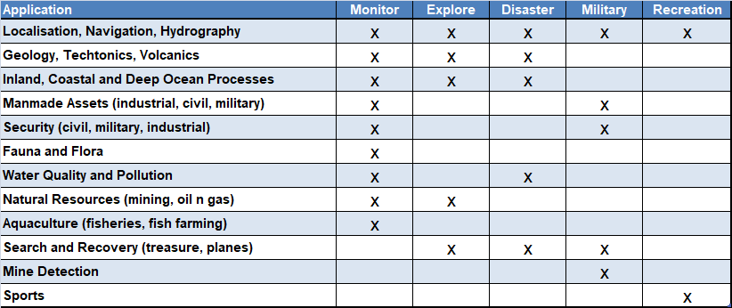

Fig.1 - IOUT Application Categories

#### Localisation, Navigation, Hydrography

Localisation under water is an issue as gps signals can not penetrate water very far. As such determining exact position of an underwater object can be challenging. This issue affects almost any IOUT application imaginable involving large water bodies. The most common solutions are:

- DVL-inertial systems, like dead reckoning, which are used for short periods/areas when no ranging can take place. The bottom is used as a relative reference.
- ranging solutions like USBL for short range locaisation, using surface transponders or LBL for long range localisation, using bottom mounted transponders.

These ranging solutions are effectively an acoustic network of sensors with known surface coordinates which act as psuedo gps satellites. The underwater object can then be localised via triangulation. Examples of usage of this type of underwater gps are oil and gas asset mantenance, search and exploration, diver localisation, UAV navigation. [3][12][13][14]

#### Geology, Techtonics, Volcanics

Monitoring of the geological environment underwater is an important usage case for IOUT. It has applications to better understanding and monitoring of the Earths structural processes which can greatly affect humans and the environment via undersea earthquakes and tsunamis. Bottom mounted sensors either connected to buoys or through buried undersea armour cable are a good example of this type of application. [15][16][17]

#### Inland, Coastal, Deep Ocean Processes

Understanding the way water is affected by and affects the weather is critical to human survival. Water movement, tides, swell, temperature, salinity among other factors impact humans and the environment near water bodies. Storm surges, large swells, extreme tides, river flooding can cause disasters and erosion. Water body processes can affect fisheries, reefs and water quality. Deep ocean currents have a strong link to the global weather system. River and lake conditions can affect flooding, fisheries, water quality. Ocean gliders (UAVs) and surface drones (ASVs), buoy and bottom mounted sensor networks are all applicable to this type of application. [40][41][42]

#### Man-made Assets

The building, monitoring and mantenance of man-made structures and vessles is a very important for military, industrial and civil applciations. Examples are monitoring of underwater pipeliness and ocean platforms and ships by fixed or mobile sensors, monitoring of bridge foundations, monitoring of naval installations. In [30], the authors go through the various connectivity options for sensors along a pipeline, from acousic to cable to tethered buoy to UAV.

#### Security

Security is essentially the securing of man-made and natural assets from unwanted intrusions. This could include anything from preventing access to sensitive military or industrial installations to protecting intrusion of unautherised actors to a fisheies area or protecting recreational ocean users from dangerous marine predators. While security applications for IOUT could involve traditional low power, low bandwidth sensor networks deployed on buoys, ships, AUVs or structures. Typically security type applications are going to need higher bandwidth connectivity or more computational power at the sensor as they will rely more on sonar imaging and object detection. [54]

#### Fauna and Flora

Aquatic fauna and flora applications are primarily monitoring. From animal tagging to detection of individual animals or groups of animals to general habitat monitoring to reef health monitoring. The target species will determine the appropriate architecture, but will typically involve sonar or acoustic/satellite tag detection for animals and fixed or mobile sensor networks for reef systems. [2][4][7][18][19][20][21][22][23][24]

#### Water Quality and Pollution

Providing clean water to communities and removing dirty water for disposal and treatment are tasks of critical importance to human civilisation as well as to the environment in general. Usage cases of IOUT are monitoring of pipeline flow and water composition as well as water supply levels and qualtiy in resovoirs. Also monitoring of flow in sewer pipes and management of water treatment plants can benefit from IOUT. Water quality is also of importance to the natural environment and can impact fisheries and reef systems. [31][32][33][34][35]

Pollution monitoring could involve anything from monitoring pollution in the water supply, to pollution in lakes and rivers to pollution in coastal regions or the open ocean. Pollution could range from chemicals, biological, thermal, plastics, micro-plastics and refuse. [35][43]

#### Natural Resources

Monitoring and exploration for in crust natural resources is of primary concern to governments and industry. [18][36][37][38][39]

#### AquaCulture

Aquaculture is the aquatic equivalent of farming and can similarly benefit from IOUT technology. As most fish farming tends to be in small geographic areas, it is well suited to take advantage of the increased automation and effficiency that IOUT can offer. Areas such as cleaning, monitoring, security, water quality, feeding can all be improved with IOUT. [1][25][26][27][28][29]

#### Search and Recovery

Search and recovery efforts are carried out by governments, private organisations and militaries. IOUT and automation can greatly improve search outcomes and reduce costs. Some notable examples are plane crash search and recovery and sunken ship search and recovery. [44]

#### Mine Detection

Mine detection is a major requirement for militaries. This is a task tailor made for IOUT, AUVs, AI and Sonar. [45][46][47][48][49]

#### Sports

Water sports of all descriptions can benefit from IOUT sensor networks, whether it be localised on-body sensors for swimming analysis to river and ocean condition sensors for outdoor aquatic sports. [50][51][52][53]

# Technological Challenges

IOT can be broken into broken into 5 component parts:

- Sensors
- Connectivity
- Platform
- Analytics
- User Interface

The first 2 categories are where the physical environment play an important role, thus we will focus the technical discussion on these 2 apects. The later 3 (Platform, Analytics, User Interface) all reside in the cloud or at the user end and as a result they are no different to the terrestrial usage case.

### Sensors

Many types of sensors can be used in an underwater setting, eg. water quality, composition, pollution, movement, temperature, pressure, vibration among others. Sensors are mounted either on surface objects (boats, buoys, ASVs), tethered to the bottom or attached to mobile (UAVs, ROVs), see the following diagrams. [3]

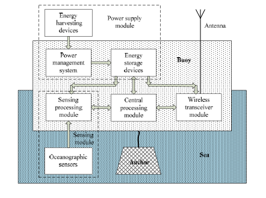

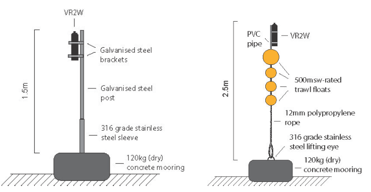

Fig.2 - Buoy and Bottom Mount Sensor Platforms [3][7]

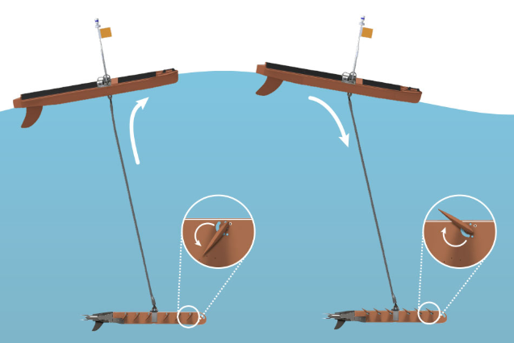

[figure not shown]

Fig.3 - Mobile UAV Platforms [LiquidRobotics][Teledyne]

#### Sensor Fouling

Many sensor types are delicate and need to be clean to operate accurately. However, unlike in a terrestrial environment where dirt and organism build up on sensors happens relatively slowly, in many underwater scenarios, fouling of sensors takes place within weeks, esspecially in warmer water. This is a known reality of operating underwater, boat owners count a major ongoing cost of ownership to defouling. With hulls needing major defouling at least yearly to minimise buildup of barnacles and grasses which affect boat drag. Sensors, unlike boat hulls, can not be painted with anti-fouling coatings, which makes them even more susceptible to fouling. There are some mechanical wiper devices that are meant to help with the sensor fouling problem, however they are not 100% effective. Besides a mechanical wiper, there are no real solutions to this major problem and as a result, over time, sensor sensitivity will gradually weaken. This is a major problem for IOUT as sending humans out to clean a sensor is expensive and difficult, much more so than for the terrestrial case. [3][4][35][55][56][57][58]

#### Sensor Corrosion

An additional problem is corrosion, in saltwater environments, certain metals and joints between dissimilar metals are very susceptible to severe corrosion. Again, this occurs at a vastly faster rate in oceanic environments compared to terrestrial cases. The workaround is to specially engineer the materials for sensors and mountings so as to avoid excessive corrosion, this adds considerable cost. [3][4][35]

#### Sensor Power Harvesting

Due to the remote nature of most large water body based sensor networks. The ability of the sensor to harvest power from the environment is of heightened importance over terrestrial sensor networks. It is difficult, time consuming and very expensive to send people to change batteries. In addition, the backhaul communications is usually over RF in the form of satellite communications which are power hungry. Energy harvesting enables sensors to be unattended for extended periods. This fact turns out to be of critical importance to the viability of many IOUT projects. [4][23][24][59][60][61]

#### Sensor Summary

In summary, the effect of the harsh underwater environment on sensor reliability is so serious, that the concept of using cheap commoditiy hardware in the field is just not viable for the aquatic case. Cheap, un-marinised sensors, housings and mountings will simply degrade and fail. The aquatic environment will find any vulnerability in the system and exploit it, leading to equipment failure. The end result of this is that customised hardware needs to be used for reliability reasons which results on orders of magnitude increases in cost for any IOUT project. It is possible to send out an RC toy boat with some sensors on the bottom to collect some data for a few days with no equipment degradation or failure[66], but this is not the same thing as deploying sensors into hostile oceans or large water bodies for months or years. A typical life-span of a hardened underwater device is 2-3 years in most cases. This, coupled with higher maintenance costs and higher equipment costs, leads to IOUT sensor networks costing significantly more than their terrestrial cousins.

### Connectivity

Connectivity is a key underlying foundational block to the IOT/IOUT concept. Sensors must connect back to the internet, this is not negotiable.

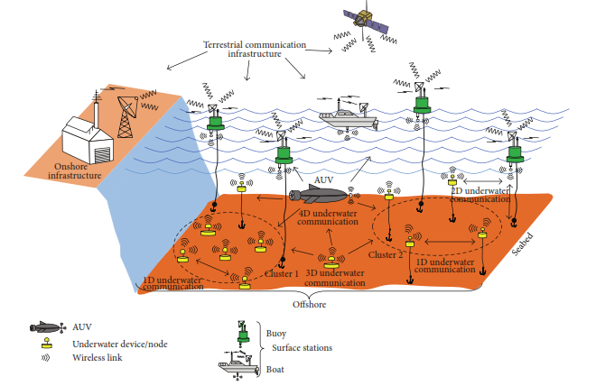

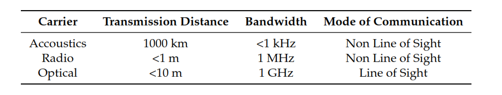

Fig.4 - IOUT Connectivity and Practical Propagation Distances[1]

#### Connectivity - RF

In the terrestrial domain, RF communications are used heavily as it is cheap, flexible and reliable. For IOUT, there is a problem, RF energy, at the same frequencies that are used on land, does not propagate through water at all well. In-part due to increased conductivity, in seawater, RF attenuation is so bad that communication of only a few meters is possible, freshwater is somewhat better, but still poor. This makes RF unsuitable for wireless communications underwater, except for some local surface communications in freshwater. Lower frequency RF radiation (sub 1KHz) can actually propagate through water and even through terrain and has been used by military’s around the globe to communicate with submarines. However because the wavelengths of this low frequency RF radiation in the order of thousands of km long,

$$\lambda_{km} = \frac{c_{water}}{100 Hz} = \frac{1\times10^5}{100} = 1000 km$$
it is extremely difficult and expensive to make a transmitter capable of transmitting at these frequencies as, among other things, the transmitting antenna needs to be a sizeable fraction of the wavelength being transmitted. It just would not be possible to create small, low power and cheap transmitters, physics will not allow it. [63]

#### Connectivity Alternatives - Optical

Optical transmission has been used in water, however optical, being EMR just like RF, also suffers from very high attenuation in water, it is also subject to water clarity issues. It is really only feasible for very short distances of a few meters with line of sight and clear water. It does have the advantage of being able to carry very large bandwidth signals, but seeing as though IOUT needs low bandwidth, this is really a mute point.

#### Connectivity Alternatives - Cable

Tethered sensors are going to be expensive and impractical for most IOUT applications. The materials, cable/cable and cable/sensor connections, cable fixings and laying the cable will all add to the cost. Physical tethering should not be forgotten however, as it can still be very useful in certain scenarios, eg. connecting a towed underwater sensor from an ocean glyder or boat or buoy, or constructing a nearshore cabled sensor network with bottom mounted sensors where the cables offer high power and data bandwidth for more complex imaging and sensing than would be possible otherwise. See [16] for a detailed depiction of a cabled underwater sensor network.

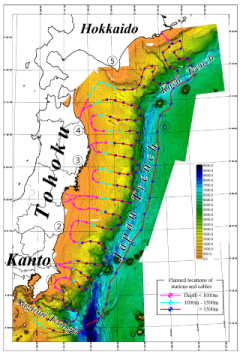

Fig.5 - Japanese Cabled Earthquake and Tsunami Alerting System[16]

#### Connectivity Alternatives - Acoustic

Acoustic energy can propagate well through water. Dolphins (0.2-150kHz) and whales (<5kHz) use it for echolocation, navigation and communications. Sound travels at approximately 1500m/s in water as opposed to 100-200 million m/s for EMR (electromagnetic radiation). Thus acoustic signals propagate ~ 100,000 times slower than EMR in water. The difference in propagation speed has some implications to the frequency bands able to be used for acoustic communications. Acoustic energy needs lower frequencies in order to propagate effectively without significant absoption effects, ideally << 100KHz for long range (>1km) transmission and < 100KHz for short range (<1km) transmission.

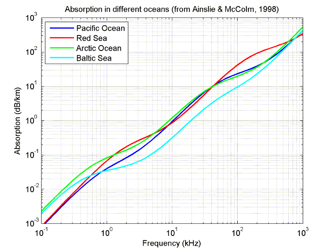

Fig.6 - Acoustic Absoption Loss vs Freq in Seawater[61]

Unlike RF, due to the much lower propagation speed, a 15kHz acoustic waveform will have a wavelength of only 10cm which makes it more practical for building transducers,

$$\lambda_{m} = \frac{1500}{15000Hz} = \frac{1500}{15000} = 0.1 m$$
The following figure gives an idealised indication of the increase in pathloss an underwater acoustic path takes for various frequencies. The model used in this simulation is very simplistic, considering only freespace and absorption losses, but it gives the general idea. [62]

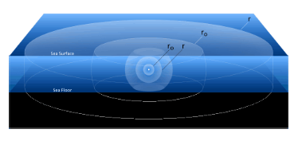

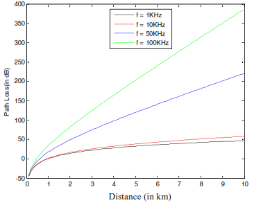

Fig.7 - Acoustic Path Loss vs Freq in Seawater (Cylindrical Propagation)[61]

Acoustic propagation in a water medium actually gets very complex to model as in addition to the basic propagation losses, there are a host of other complex effects that become significant to the attenuation under different conditions and for different frequencies [5]. The complicating effects cause acoustic propagation to be notoriously difficult to model generally over a wide range of conditions and frequencies. Some of the complicating effects are caused by pressure gradients, temperature gradients, doppler effects, water composition differences, water column depth, bottom material and morphology, surface wave state and the amount and location of bubbles from turbulence.[2][5][10][62][66] In comparison, radio signals in a terrestrial scenario also suffer from many complicating effects and can also be difficult to model accurately. However, under many usage scenarios, most of these effects are not dominant and can be approximated or ignored. Thus making RF propagation modelling somewhat easier than for the acoustic case. Some of the big impacts of acoustic specific issues to data transfer are:

- the high propagation delay - this causes issues with high speed data communications, we simply can not effectively send high speed data if the channel delay is much larger than the symbol rate. The excessive propagation delay also affects protocol design due to the inability to effectively use retransmissions and to avoid collisions.
- the extreme potential of multipath and fading in water. Multipath and fading can cause issues for any communication system. In water, multipath and fading can be much stronger than that which is observed in radio channels on land due to surface/bottom reflections and scattering as well a host of other more complex effects, the end result is a reduction in usable transmission distance for a given modulation scheme, frequency, data rate.
- the baseband bandwidth of the data symbol rate should ideally be << carrier bandwidth for effective modulation. As acoustic modems are using the 5-200kHz carrier bands, this puts a limit of the baseband (symbol rate) that can be effectively modulated on these carriers. This is in contrast to radio where the common carrier frequencies of 500MHz to 5GHz are able to support baseband symbol rates of 10Msps easily.
- the unpredictable attenuation loss due to absorption and obstacles in the underwater environment.
- the effects that acoustic energy have on dolphins and whales. It has been shown that whale communications have changed in recent history and it is postulated that this is partly due to the increased amount of acoustic noise in the ocean. Even if the noise is outside of the primary bands used by a specific creature, it still has been shown to have an impact, ref: Shipping noise impacts on marine life, [6][8][9][64]

In terms of how far can acoustic modems be realistically used, the following paper describes and tests a system for low bandwidth data transmission (100bps) up to 1000kms in deep water at ~ 500Hz [63]. However, this system uses a large amount of power. More realistic low bandwidth, low power acoustic modems such as the Teledyne Benthos [www.teledynemarine.com/benthos] operate between 9-27kHz and can obtain data rates from 80bps at 6km+ to 15kbps at shorter distances. These more trusted modems use older modulation techniques, such as frequency hopping and PSK. Newer modulation techniques such as direct sequenc spread spectrum, chirp spread spectrum and ofdm are now being developed as they offer better resistance to multipath, frequency selective fading and interference. Aquacomm [www.dspcommgen2.com] specifically manufacture DSSS modems operating in the 10-30kHz range that are low power, low bandwidth (100-500bps) and can operate into the multi km ranges. Water-Linked [www.waterlinked.com], in contrast, make a 100-200kHz band transducer supporting 64bps up to 200m. In general, the lower the transmission distance, the smaller and cheaper the modem. Going below 1km will significantly reduce the power requirement and size of the modem.

#### Connectivity Summary

In summary, the connectivity issues with IOUT have some major impacts on which architectures are viable. The following deployment depictions from Teledyne give an indication of what is realistic for IOUT.

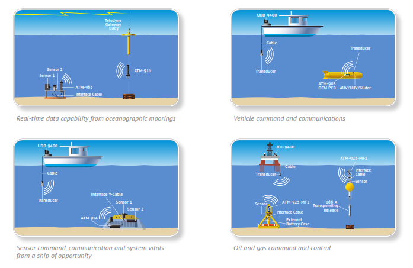

Fig.8 - Acoustic Modem Usage Cases

The basic concept is to use acoustic to communicate underwater if required, either node to node or node to gateway. At some point the communications must reach the surface where a buoy, ship, ASV or structure will relay data over the air via RF to another gateway or satellite. In many cases [4], underwater communications has been forgone altogether in favour of surface buoys which have underwater sensors and above water RF links to each other.

Regardless of the strategy, underwater communications limitations will effectively limit the size and spread of any IOUT UWSNs to local areas, or to usage cases which are of such social or financial benefit that the financial costs of larger scale deployments are less restrictive, i.e. oil and gas or large government projects such as the Western Australian Government shark monitoring network, a subsection of this network is shown in the following figure.

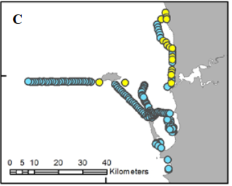

Fig.9 - Acoustic Receiver Network Perth, WA Govt.[7]

# Conclusion

As with terrestrial IOT, IOUT has not escaped the hype machine. This paper attempted to counter the hype with some realism. There is no doubt as to the potential benefit from UWSNs to human civilisation and the environment, given that water covers the majority of the planet’s surface, even a small improvement in the understanding and monitoring of the aquatic realm will reap benefits. However the harsh aquatic environment disarms some of the core drivers of the IOT mentality. Deployments will not be simple, cheap and low mantenance, these are areas that need to be further researched to remove adoption barriers, but physics will ultimately limit how far IOUT can go.

Lastly, the point should be made that while this paper attempts to isolate IOUT from any other type of sensor network for the sake of focus, the reality is that IOUT will form part of larger sensor networks that include terrestrial IOT and airborne/spaceborne remote sensing. While not the focus of this paper, it is clear that UAV, long range radar and satellite remote sensing is an area of massive potential given that it can fully utilise the power of the electro-magnetic spectrum, enabling man to observe large areas of remote ocean real-time. IOUT will most likely be a valuable partner in a composite system of sensor networks, not an isolated player.

# References

1. A Comprehensive Study on the Internet of Underwater Things: Applications, Challenges, and Channel Models; Chien-Chi Kao, Geng-De Wu, Yi-Shan Lin, Chun-Ju Huang
2. Underwater Sensor Network Applications: A Comprehensive Survey; Emad Felemban, Adil A. Sheikh, Faisal Karim Shaikh, Saad Bin Qaisar, Umair Mujtaba Qureshi
3. Applications of Wireless Sensor Networks in Marine Environment Monitoring: A Survey; Guobao Xu, Weiming Shen, Xianbin Wang
4. Lessons from the Field-Two Years of Deploying Operational Wireless Sensor Networks on the Great Barrier Reef Scott Bainbridge, Damien Eggeling and Geoff Page
5. L.M. Brekhovskikh, Yu.P. Lysanov; Fundamentals of Ocean Acoustics 3rd Ed.; Book, Springer 2003
6. M.A. McDonald, J.A. Hildebrand, S.Mesnick; Worldwide decline in tonal frequencies of blue whale songs
7. R.McAuley, B.Bruce, I.Keay, S.Mountford, T.Pinnell; Evaluation of passive acoustic telemetry approaches for monitoring and mitigating shark hazards off the coast of Western Australia; Department of Fisheries, Government of Western Australia, 2016
8. O.B.Wilson Jr., S.N.Wolf, F.Ingenito; Measurements of Acoustic Ambient Noise in Shallow Water Due to Breaking Surf, Naval Postgraduate School 1982
9. D.H. CATO; Shipping noise impacts on marine life; Defence Science and Technology Organisation and University of Sydney, Sydney, Australia
10. G. Ac¸ ar and A.E. Adams; ACMENet: an underwater acoustic sensor network protocol for real-time environmental monitoring in coastal areas
11. Guangjie Han, Aihua Qian, Chenyu Zhang, Yan Wang, J.J.P.C.Rodrigues; Localization Algorithms in Large-Scale Underwater Acoustic Sensor Networks: A Quantitative Comparison; International Journal of Distributed Sensor Networks, 2014
12. M.Waldmeyer, H.P.Tan, W.K.G.Seah; Multi-stage AUV aided localization for underwater wireless sensor networks; Proceedings of the IEEE International Conference on Advanced Information Networking and Applications Workshops (WAINA ’11), pp. 908-913, March 2011.
13. Y. Guo and Y. Liu, “Localization for anchor-free underwater sensor networks,” Computers & Electrical Engineering,vol.39, no. 6, pp. 1812-1821, 2013.
14. P.Carroll,S.Zhou,K.Mahmood,H.Zhou,X.Xu,andJ.-H.Cui, “On-demand asynchronous localization for underwater sensor networks,” in Proceedings of the IEEE Oceans, pp. 1-4, IEEE, Hampton Roads, Va, USA, October 2012.
15. K. Casey, A. Lim, and G. Dozier, “A sensor network architecture for tsunami detection and response,” International Journal of Distributed Sensor Networks,vol.4,no.1,pp.28-43,2008.
16. T. Kanazawa, “Japan Trench earthquake and tsunami monitoring network of cable-linked 150 ocean bottom observatories and its impact to earth disaster science,” in Proceedings of the IEEE International Underwater Technology Symposium (UT ’13),5,p. 1, March 2013.
17. Casey, K.; Lim, A.; Dozier, G. A sensor network architecture for tsunami detection and response. Int. J. Distrib. Sens. Netw. 2008, 4, 27-42.
18. G. Ac¸ar and A. E. Adams, “ACMENet: an underwater acoustic sensor network protocol for real-time environmental monitoring in coastal areas,” IEE Proceedings: Radar, Sonar and Navigation,vol.153,no.4,pp.365-380,2006.
19. J. Trevathan, R. Johnstone, T. Chiffings et al., “SEMAT-the next generation of inexpensive marine environmental monitoring and measurement systems,” Sensors,vol.12,no.7,pp.9711-9748, 2012
20. C. A. Perez, M. Jimenez, F. Soto, R. Torres, J. A. Lopez, and A. Iborra, “A system for monitoring marine environments based on wireless sensor networks,” in Proceedings of the IEEE OCEANS, pp. 1-6, IEEE, Santander, Spain, June 2011.
21. S.Zhang,J.Yu,A.Zhang,L.Yang,andY.Shu,“Marinevehicle sensor network architecture and protocol designs for ocean observation,” Sensors,vol.12,no.1,pp.373-390,2012.
22. G. Xu, W. Shen, and X. Wang, “Applications of wireless sensor networks in marine environment monitoring: a survey,” Sensors, vol.14,no.9,pp.16932-16954,2014.
23. C. Alippi, R. Camplani, C. Galperti, and M. Roveri, “A robust, adaptive, solar-powered WSN framework for aquatic environmental monitoring,” IEEE Sensors Journal,vol.11,no.1,pp.45- 55, 2011.
24. A. Pirisi, F. Grimaccia, M. Mussetta et al., “Optimization of an energy harvesting buoy for coral reef monitoring,” in Proceedings of the IEEE Congress on Evolutionary Computation (CEC ’13), pp. 629-634, IEEE, Cancun, Mexico, June 2013.
25. A.YalcukandS.Postalcioglu,“Evaluationofpoolwaterquality of trout farms by fuzzy logic: monitoring of pool water quality for trout farms,” International Journal of Environmental Science and Technology,vol.12,no.5,pp.1503-1514,2015.
26. J. Lloret, S. Sendra, M. Garcia, and G. Lloret, “Group-based underwater wireless sensor network for marine fish farms,” in Proceedings of the IEEE GLOBECOM Workshops (GC Wkshps ’11), pp. 115-119, IEEE, Houston, Tex, USA, December 2011.
27. M.Lpez,S.Martnez,J.Gmezetal.,“Wirelessmonitoringofthe pH, NH4 and temperature in a fish farm,” Procedia Chemistry, vol. 1, no. 1, pp. 445-448, 2009.
28. L. A. Abdul-Rahaim and A. M. A. Ali, “Remote wireless automation and monitoring of large farm using wireless sensors networks and internet,” International Journal of Computer Science & Engineering Technology,vol.6,no.3,pp.118-137,2015.
29. N.Nasser,A.N.K.Zaman,L.Karim,andN.Khan,“CPWS: an efficient routing protocol for RGB sensor-based fish pond monitoring system,” in Proceedings of the IEEE 8th International Conference on Wireless and Mobile Computing, Networking and Communications (WiMob ’12), pp. 7-11, October 2012.
30. N.Mohamed,I.Jawhar,J.Al-Jaroodi,andL.Zhang,“Sensor network architectures for monitoring underwater pipelines,” Sensors, vol. 11, no. 11, pp. 10738-10764, 2011.
31. G. Tuna, O. Arkoc, and K. Gulez, “Continuous monitoring of water quality using portable and low-cost approaches,” International Journal of Distributed Sensor Networks,vol.2013, Article ID 249598, 11 pages, 2013.
32. K. Menon, P. Divya, and M. Ramesh, “Wireless sensor network for river water quality monitoring in India,” in Proceedings of the 3rd International Conference on Computing Communication Networking Technologies (ICCCNT ’12),pp.1-7,July2012.
33. A.Faustine,A.N.Mvuma,H.J.Mongi,M.C.Gabriel,A.J. Tenge, and S. B. Kucel, “Wireless sensor networks for water quality monitoring and control within lake victoria basin: prototype development,” Wireless Sensor Network,vol.06,no. 12, pp. 281-290, 2014.
34. M.Shakir,M.A.Khan,S.A.Malik,andIzhar-ul-Haq,“Design of underwater sensor networks for water quality monitoring,” World Applied Sciences Journal,vol.17,no.11,pp.1441-1444, 2012
35. A. Khan and L. Jenkins, “Undersea wireless sensor network for ocean pollution prevention,” in Proceedings of the 3rd International Conference on Communication Systems Software and Middleware and Workshops,pp.2-8,Bangalore,India, January 2008.
36. B. Thornton, A. Bodenmann, A. Asada, T. Sato, and T. Ura, “Acoustic and visual instrumentation for survey of manganese crusts using an underwater vehicle,” in Proceedings of the OCEANS,pp.1-10,October2012.
37. J. Heidemann, W. Ye, J. Wills, A. Syed, and Y. Li, “Research challenges and applications for underwater sensor networking,” in Proceedings of the IEEE Wireless Communications and Networking Conference (WCNC ’06), pp. 228-235, April 2006.
38. I. F. Akyildiz, D. Pompili, and T. Melodia, “Underwater acoustic sensor networks: research challenges,” Ad Hoc Networks,vol.3, no.3,pp.257-279,2005.
39. S. Srinivas, P. Ranjitha, R. Ramya, and G. Narendra, “Investigation of oceanic environment using large-scale uwsn and uanets,” in Proceedings of the 8th International Conference on Wireless Communications, Networking and Mobile Computing (WiCOM ’12), pp. 1-5, September 2012.
40. A. A. Pasi and U. Bhave, “Flood detection system using wireless sensor network,” International Journal of Advanced Research in Computer Science and Software Engineering,vol.5,no.2,pp. 386-389, 2015.
41. R. Marin-Perez, J. Garc´ia-Pintado, and A. S. G´omez, “A realtime measurement system for long-life flood monitoring and warning applications,” Sensors,vol.12,no.4,pp.4213-4236, 2012
42. E. N. Udo and E. B. Isong, “Flood monitoring and detection system using wireless sensor network,” Asian Journal of Computer and Information Systems,vol.1,no.4,pp.108-113,2013.
43. Lee, H.C.; Banerjee, A.; Fang, Y.M.; Lee, B.J.; King, C.T. Design of a multifunctional wireless sensor for in situ monitoring of debris flows. IEEE Trans. Instrum. Meas. 2010, 59, 2958-2967.
44. Tongwei Zhang , Shengjie Qin, Xiangxin Wang, Jialing Tang; Deep-sea search and recovery: with and without operating an underwater vehicle; Journal of Ocean Science 2018
45. S. Kumar, A. Perry, C. Moeller et al., “Real-time tracking magnetic gradiometer for underwater mine detection,” in Proceedings of the OCEANS ’04 and MTTS/IEEE TECHNOOCEAN ’04,vol.2,pp.874-878,November2004.
46. D. P. Williams, “On optimal AUV track-spacing for underwater mine detection,” in Proceedings of the IEEE International Conference on Robotics and Automation (ICRA ’10),pp.4755-4762, IEEE, Anchorage, Alaska, USA, May 2010.
47. C. Rao, K. Mukherjee, S. Gupta, A. Ray, and S. Phoha, “Underwater mine detection using symbolic pattern analysis of sidescan sonar images,” in Proceedings of the American Control Conference (ACC ’09),pp.5416-5421,June2009.
48. S. Khaledi, H. Mann, J. Perkovich, and S. Zayed, “Design of an underwater mine detection system,” in Proceedings of the IEEE Systems and Information Engineering Design Symposium (SIEDS ’14), pp. 78-83, April 2014.
49. C.Barngrover,R.Kastner,andS.Belongie,“Semisynthetic versus real-world sonar training data for the classification of mine-like objects,” IEEE Journal of Oceanic Engineering,vol.40, no. 1, pp. 48-56, 2015.
50. F. A. D. Magalhaes, G. Vannozzi, G. Gatta, and S. Fantozzi, “Wearable inertial sensors in swimming motion analysis: a systematic review,” Journal of Sports Sciences,vol.33,no.7,pp. 732-745, 2015.
51. T. Le Sage, P. Conway, L. Justham, S. Slawson, A. Bindel, and A. West, “A component based integrated system for signal processing of swimming performance,” in Proceedings of the InternationalConferenceonSignalProcessingandMultimedia Applications (SIGMAP ’10), pp. 73-79, IEEE, Athens, Greece, July 2010.
52. R. M. Hagem, S. G. O’Keefe, T. Fickenscher, and D. V. Thiel, “Self contained adaptable optical wireless communications system for stroke rate during swimming,” IEEE Sensors Journal,vol.13, no. 8, pp. 3144-3151, 2013.
53. N.Chakravorti,T.LeSage,S.E.Slawson,P.P.Conway, and A. A. West, “Design and implementation of an integrated performance monitoring tool for swimming to extract stroke information at real time,” IEEE Transactions on HumanMachine Systems,vol.43,no.2,pp.199-213,2013.
54. A. Caiti, V. Calabr`o, A. Munaf`o, G. Dini, and A. Lo Duca, “Mobile underwater sensor networks for protection and security: field experience at the UAN11 experiment,” Journal of Field Robotics,vol.30,no.2,pp.237-253,2013.
55. Delauney, L.; Compère, C.; Lehaitre, M. Biofouling protection for marine environmental sensors. Ocean Sci. 2010, 6, 503-511.
56. Yebra, D.M.; Kiil, S.; Dam-Johansen, K. Antifouling technology-past, present and future steps towards efficient and environmentally friendly antifouling coatings. Prog. Org. Coat. 2004, 50, 75-104.
57. Whelan, A.; Regan, F. Antifouling strategies for marine and riverine sensors. J. Environ. Monit. 2006, 8, 880-886.
58. Manov, D.V.; Chang, G.C.; Dickey, T.D. Methods for reducing biofouling of moored optical sensors. J. Atmos. Ocean. Technol. 2004, 21, 958-968.
59. Pirisi, A.; Grimaccia, F.; Mussetta, M.; Zich, R.E.; Johnstone, R.; Palaniswami, M. Optimization of an Energy Harvesting Buoy for Coral Reef Monitoring. In Proceedings of the 2013 IEEE Congress on Evolutionary Computation, Cancún, Mexico, 20-23 June 2013; pp. 629-634.
60. Seah, W.K.G.; Zhi, A.E.; Tan, H. Wireless sensor networks powered by ambient energy harvesting (WSN-HEAP)-Survey and challenges. In Proceedings of the 1st International Conference on Wireless Communication, Vehicular Technology, Information Theory and Aerospace & Electronic Systems Technology, Aalborg, Denmark, 17-20 May 2009; pp. 1-5.
61. Cesare, A.; Cristian, G. An adaptive system for optimal solar energy harvesting in wireless sensor network nodes. IEEE Trans. Circuits Syst. I Regul. Pap. 2008, 55, 1742-1750.
62. Prof. G. Sasi Bhushana Rao, D. Eswara Chaitanya, Ch. Vasavi Sridevi; Path loss analysis of Underwater communication systems; IEEE Students Tecynology Syposium 2011
63. F.Mosca, G.Matte, T.Shimura; Low-frequency acoustic source for AUV long-range communication; Jamstec
64. W.W.L.Au, P.E.Nachtigall, J.L.Pawloski; Acoustic effects of the ATOC signal (75 Hz, 195 dB) on dolphins and whales; Marine Mammal Research Program, Hawaii Institute of Marine Biology, University of Hawaii
65. Umair Mujtaba Qureshi, Faisal Karim Shaikh, Zuneera Aziz, Adil A. Sheikh, Emad Felemban, Saad Bin Qaisar; RF Path and Absorption Loss Estimation for Underwater Wireless Sensor Networks in Different Water Environments; Sensors 2016
66. E.M.Sozer, M.Stojanovic, J.G.Proakis; Underwater Acoustic Networks; IEEE 2000
67. S.Sukaridhoto, D.Pramadihanto, Taufiqurrahman, M.Alif, A.Yuwono, N.Funabiki; A Design of Radio-Controlled submarine Modification for River Water Quality Monitoring; 2015 International Seminar on Intelligent Technology and Its Applications